# assignment 5

Oyedayo Oyelowo

2 November 2017

```r
#clear memory
rm(list = ls())
setwd("C:/Users/oyeda/Desktop/R_COURSE/assignment5")
#load the data
data<-read.table("puudata.txt", header = T, sep = "\t")
```

## Exercise 1

- **a) Plot the height of living crown (ELAVALARAJA) as a function of height (PITUUS). Try using dots and lines. Which one is better?**

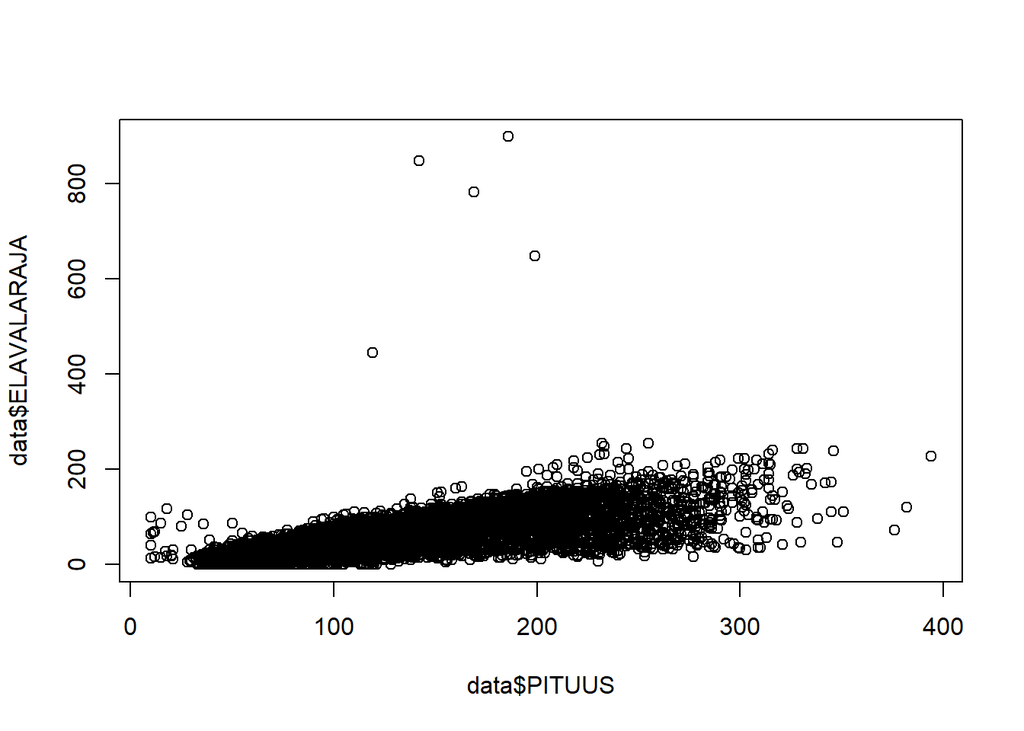

```r
plot(data$ELAVALARAJA~data$PITUUS,  type = "p")
```

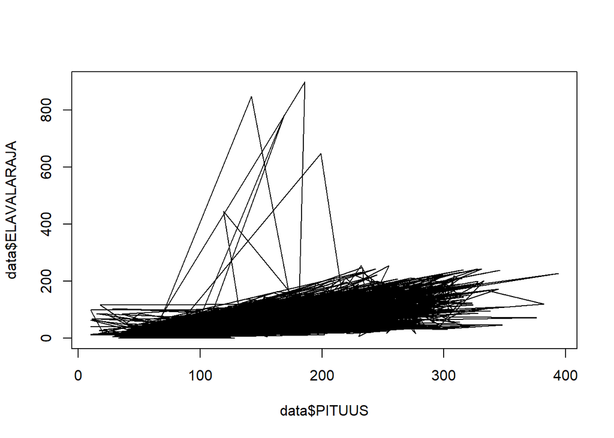

```r
plot(data$ELAVALARAJA~data$PITUUS, type = "l")
```

- ** Answer: The dots plot is better.**
- **b) Exclude the incorrect data entries (height of living crown over 40 meters) out of the picture by changing limits of x- and y-axis.**
- **c) Give proper names for both of the axes**
- **d) Add a line x = y to the picture. How would you describe the observation on the line? What about on top of the line?**

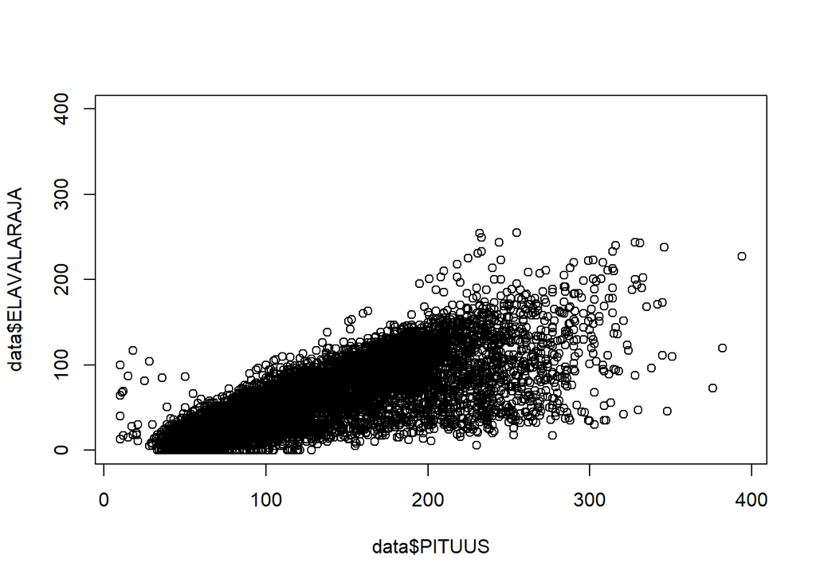

```r
#b) Exclude the incorrect data entries (height of living crown
#over 40 meters) out of the picture by changing limits of x- and y-axis.
#?plot
plot(data$ELAVALARAJA~data$PITUUS, type = "p", ylim = c(0,400))
```

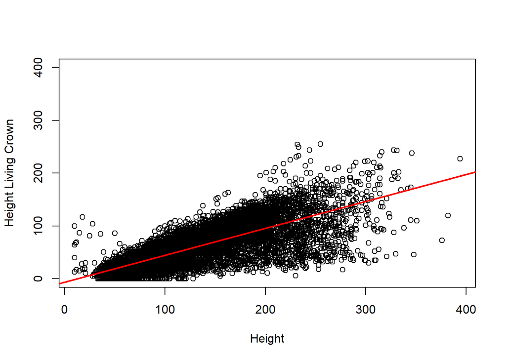

```r
plot(ELAVALARAJA~PITUUS , data=data,   ylim=c(0,400),
     xlab = "Height", ylab = "Height Living Crown")
#?~

#c) Give proper names for both of the axes
plot(ELAVALARAJA~PITUUS, data=data, type = "p", ylim = c(0,400),
     xlab = "Height", ylab = "Height Living Crown")
fit <- lm(ELAVALARAJA~PITUUS, data = data)
abline(fit, col="red", lwd=2)
```

**The observations on the line are those where the predictions with zero vertical deviation and fit with the prediction while those on top are the positive residuals**

### Exercise 2

- **a) Plot height of the birches (PUULAJI=3) in the first canopy coverlayer as a function of the tree diameter.**

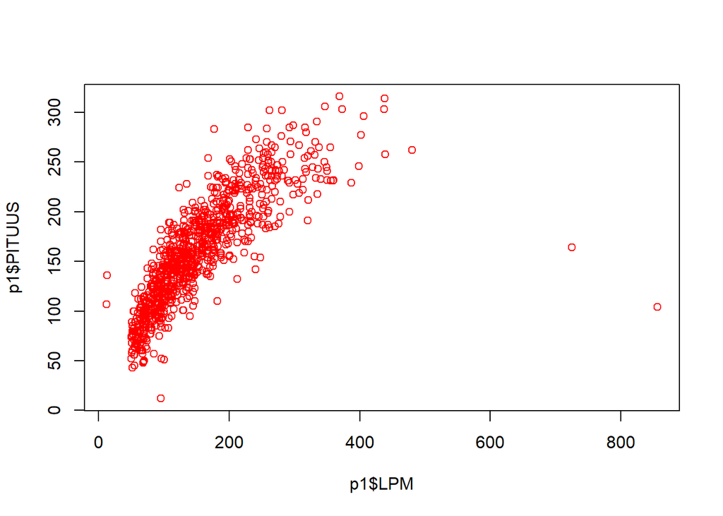

```r
p1<-subset(data, PUULAJI==3 &  LATVKERROS==1)
plot(p1$LPM, p1$PITUUS, col="red")
```

```r
#or
#plot(p1$PITUUS~p1$LPM, col="green")
#or
#plot(PITUUS~LPM, p1)
```

- **b) Change the picture so that the observations are drawn as green circles with black border.**

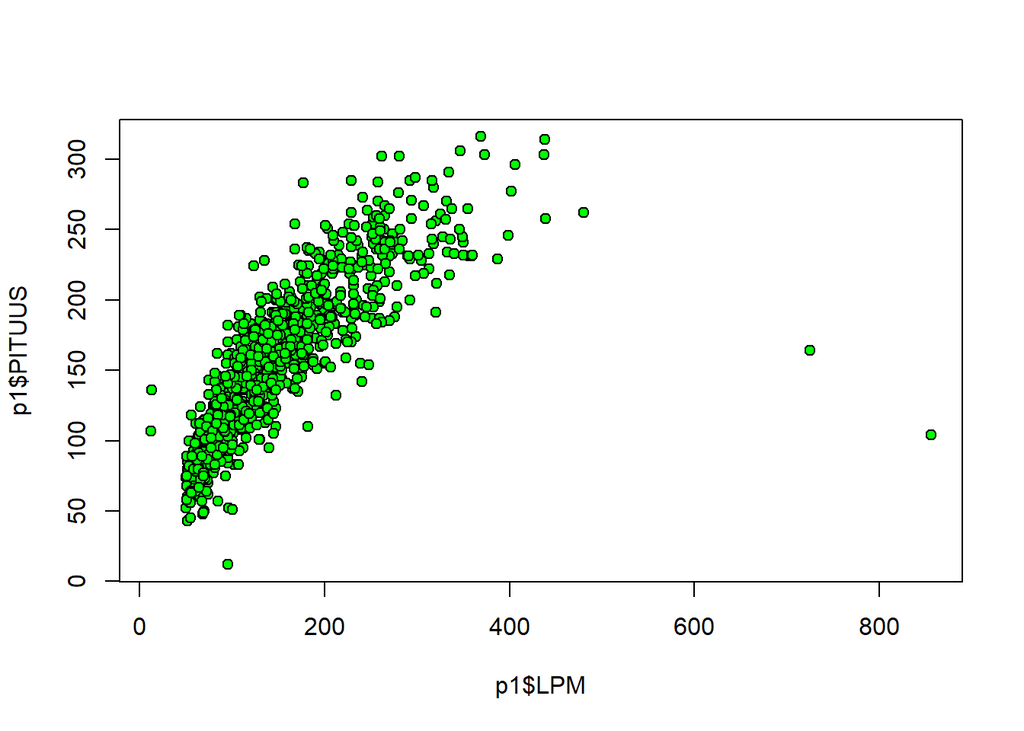

```r
plot(p1$LPM, p1$PITUUS,pch= 21,col="black",type= "p", bg= "green")
```

- **c) Change the style of the two differing observations as red triangles with black border (form a new subset and draw it with points function)**

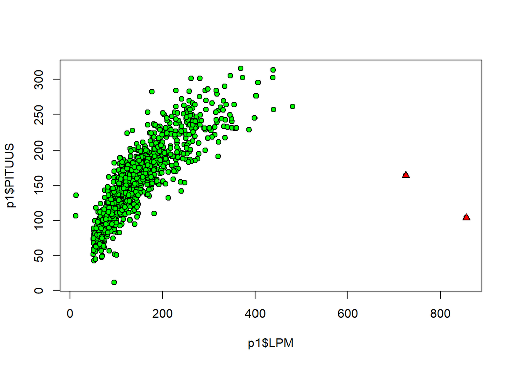

```r
plot(p1$LPM, p1$PITUUS,pch= 21,col="black",type= "p", bg= "green")
p2<-p1[p1["LPM"]>600,]
points(p2$LPM, p2$PITUUS, pch = 24, col ="black", bg = "red")
```

## Exercise 3 Exercise 2 continues.

- 1. Add line y=250 to the picture.
- 2. Determine the color as red and the line width as 2.
- 3. Add a line that travels through origin (point (0,0))and has slope value of 1.1. Use dashed line type and choose some nice color (available colors can be found with command colors()).
- 4. Add a text into the formed rectangle (on lower right corner) that says “Erroneous observations”.

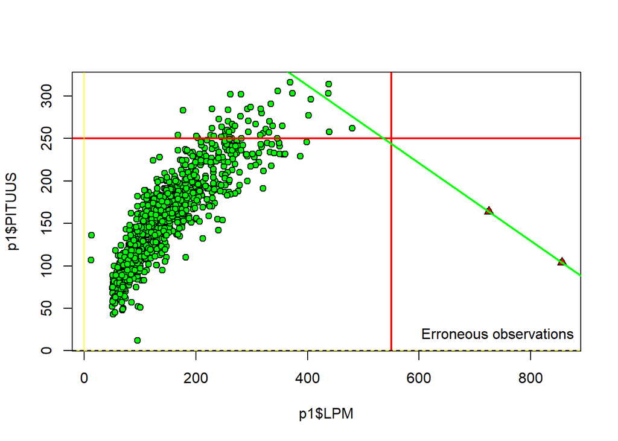

```r
plot(p1$LPM, p1$PITUUS,pch= 21,col="black",type= "p", bg= "green")
p2<-p1[p1["LPM"]>600,]
#points(p2$LPM, p2$PITUUS, pch = 24, col ="black", bg = "red")
points(p2$LPM, p2$PITUUS, ylab = "Height",xlab = "DBH", pch = 24, col ="black", bg = "red")
#abline(h=250, v=0,lwd=2,col="red")
abline(h=250,lwd=2,col="red")

#?abline
#b) Add line x=550 to the picture and use the same styles.
abline(v=550,lwd=2,col="red")
abline(b=1.1, lwd=2, col="green", lm(PITUUS ~LPM, data = p2))
abline(h=0, v=0,b=1.1, col = "yellow")
abline(h = 0, lty = 2)

# Add text
# Add text using the following Corner_text function:

#create function to add text
text_corner <- function(text, position="bottomright"){
  legend(position,legend=text, bty ="n", pch=NA)
}

#use the function to add the legend.
#NOTE: I can do this directly, Just trying my hands on using
#functions
text_corner(text="Erroneous observations", position= "bottomright")
```

### Exercise 4

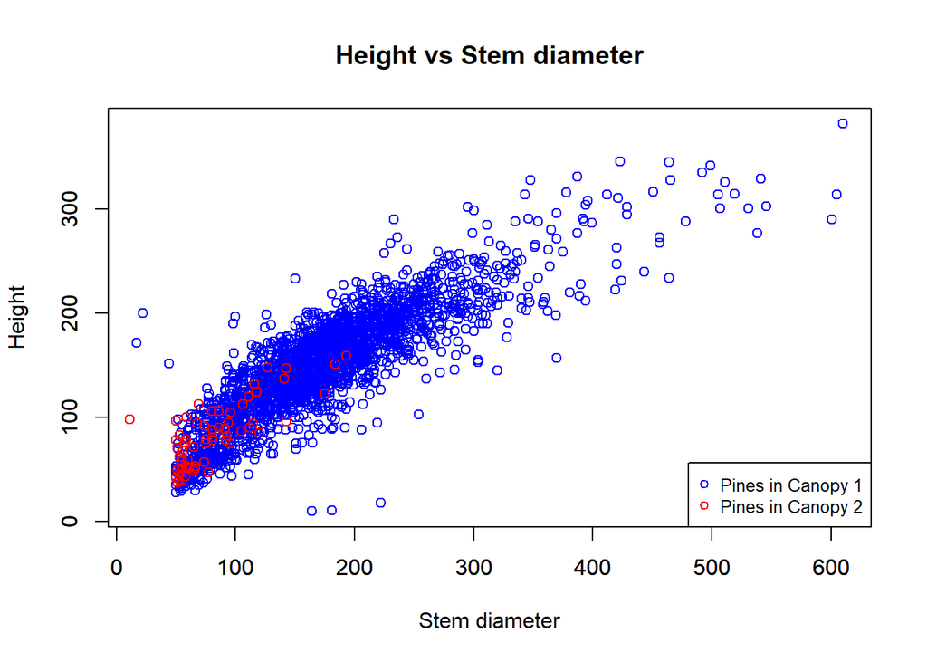

```r
#canopy cover layer as a function of stem diameter.
pines_canopy1 <- subset(data, data$PUULAJI==1 & data$LATVKERROS==1)
pines_canopy2 <- subset(data, data$PUULAJI==1 & data$LATVKERROS==2)

#plot height as a function of stem diameter
{plot(PITUUS ~ LPM, pines_canopy1, xlab="Stem diameter", ylab="Height",
     main="Height vs Stem diameter",col="blue")


#alternatives
#plot(data$LPM, data$PITUUS)
#plot(data$PITUUS ~ data$LPM)

par(new=T)
plot(PITUUS ~ LPM, pines_canopy2, xlim=c(min(pines_canopy1$LPM),
     max(pines_canopy1$LPM)), xlab=NA, ylab=NA,
     ylim=c(min(pines_canopy1$PITUUS),max(pines_canopy1$PITUUS)),
     col="red")

legend("bottomright", legend=c("Pines in Canopy 1", "Pines in Canopy 2"),
       col=c("blue", "red"), pch = 1, cex=0.8)
#instead of using bottomright, a coordinate for the legend can
#also be used. e,g 410, 190

}
```

```r
#alternatively, this can be done by plotting for the first,
#and basically adding points from the second data

#{plot(PITUUS ~ LPM, pines_canopy1, xlab="Stem diameter", ylab="Height",
#     main="Height vs Stem diameter",col="blue")

#points(pines_canopy2$LPM, pines_canopy2$PITUUS, pch=1, col="red")
# Add a legend
#legend("bottomright", legend=c("Pines in Canopy 1", "Pines in Canopy 2"),
#       col=c("blue", "red"), pch = 1, cex=0.8)
#}
```

*From the plot, it can be deduced that the first canopy of the Pines Species account mostly for the height- Stem diameter relationship.*